# 4 - Modelo ARX

## 4.1 Descripción

El cuarto modelo a utilizar es un modelo autoregresivo con entrada exógena, $\text{ARX}(n_a, n_b)$, definido como:

\begin{equation} y(t) + a_1 y(t-1) + \dots + a_{n_a}y(t-n_a) = b_1 u(t-1) + \dots + b_{n_b} u(t - n_b) + e(t) \end{equation}

donde $n_a$ es el orden de la regresión y $n_b$ es el orden de la entrada exógena.

## 4.2 Cargamos el conjunto de datos

Importamos las librerías

```python
# Importamos las librerias necesarias para trabajar
from statsmodels.regression.linear_model import yule_walker
from statsmodels.graphics.tsaplots import plot_acf
from sklearn.metrics import mean_squared_error
from numpy.fft import fft, fftfreq, fftshift
from mpl_toolkits.mplot3d import Axes3D
from scipy import signal
from matplotlib import cm
from datetime import time
from matplotlib import rc
import matplotlib.pyplot as plt
import matplotlib.dates as mdates
import mysql.connector
import seaborn as sns
import pandas as pd
import numpy as np
import datetime
import copy
import sklearn

# Seteamos el estilo de los graficos
sns.set(style="whitegrid")

# Configuramos los graficos con latex
plt.rc('text', usetex=True)

# Funcion para la metrica de la trayectoria
def error_trayectoria(vector):
    '''
    Se calcula una norma de error como la diferencia entre la prediccion y la medicion
    real para un tiempo t. Se utilizara la norma euclidiana
    '''
    y_predict = vector['y+1':'y+6']
    y_real = vector['y']
    error = (y_predict - y_real) ** 2
    error = sum(error) / len(error)
    return np.sqrt(error)

def phi_X(R_X, gamma, Ts=5 * 60):
    arg_max = R_X.argmax()
    R_X_wind = R_X[arg_max - gamma: arg_max + gamma + 1]
    wind = np.hanning(len(R_X_wind))
    phi_X = fft(R_X_wind * wind)
    freq = fftfreq(len(phi_X), Ts)
    phi_X = pd.Series(phi_X, index=freq)
    phi_X = phi_X[freq > 0]
    return phi_X
```

```python
# Abrimos la base de datos
mydb = mysql.connector.connect(
    host='localhost',
    user='root',
    password='7461143',
    database='datos_ordenados'
)

# Extraemos la informacion en un dataframe
df = pd.read_sql("SELECT * FROM cgm_ordenados", mydb)   # Cargamos todos los datos
#df.drop('id', axis=1, inplace=True)                   # Eliminamos el indice
df.set_index('datetime', inplace=True)                # Definimos datetime como indice
df.sort_index(inplace=True)                           # Ordenamos en base a datetime
df.index.freq = pd.infer_freq(df.index)
# Mostramos los resultados
print('Tamano de la tabla: {} filas y {} columnas'.format(df.shape[0], df.shape[1]))
print('Tiempo del estudio:')
print(' - Inicio  : {}'.format(str(df.index[0])))
print(' - Final   : {}'.format(str(df.index[-1])))
print(' - Duración: {}'.format(str(df.index[-1] - df.index[0])))
df.head(3)
```

```
Tamano de la tabla: 1728 filas y 6 columnas
Tiempo del estudio:
 - Inicio  : 2020-01-24 17:00:00
 - Final   : 2020-01-30 16:55:00
 - Duración: 5 days 23:55:00
```

| datetime | sensor_glucose | sensor_calibration_bg | meal | basal_insulin | bolus_insulin | exercise |
| --- | --- | --- | --- | --- | --- | --- |
| 2020-01-24 17:00:00 | NaN | 125.0 | NaN | NaN | NaN | NaN |
| 2020-01-24 17:05:00 | 126.0 | NaN | NaN | NaN | NaN | NaN |
| 2020-01-24 17:10:00 | 128.0 | NaN | NaN | NaN | NaN | NaN |

Extraemos y procesamos las variables utilizadas para el modelo. Estas se guardaran en un archivo `.csv` para ser procesados por MATLAB

```python
# en este caso, solo es la variable de la glucosa
y = copy.copy(df['sensor_glucose'])
u_meal = copy.copy(df['meal'])
u_bolo = copy.copy(df['bolus_insulin'])
# Realizamos una interpolacion para eliminar los NaN
y.interpolate(inplace=True, limit_direction='both')
u_meal.replace(np.nan, 0, inplace=True)
u_bolo.replace(np.nan, 0, inplace=True)
# Cambiamos el nombre de la variable a y (por simplicidad a futuro)
y.rename('y', inplace=True)
u_meal.rename('u_meal', inplace=True)
u_bolo.rename('u_bolo', inplace=True)
# Por comodidad, se trabajara con los datos como Dataframe y no como Serie
data = pd.concat([y,u_meal,u_bolo], axis=1)
data.to_csv('data_from_pandas.csv', sep=';')
data.head(5)
```

| datetime | y | u_meal | u_bolo |
| --- | --- | --- | --- |
| 2020-01-24 17:00:00 | 126.0 | 0.0 | 0.0 |
| 2020-01-24 17:05:00 | 126.0 | 0.0 | 0.0 |
| 2020-01-24 17:10:00 | 128.0 | 0.0 | 0.0 |
| 2020-01-24 17:15:00 | 146.0 | 0.0 | 0.0 |
| 2020-01-24 17:20:00 | 158.0 | 0.0 | 0.0 |

```python
# Parametros
fecha_limite = '2020-01-28 16:59:59'
data_train = copy.copy(data[:fecha_limite])
data_test = copy.copy(data[fecha_limite:])
print('- porcentaje de training: {:2.2f}%'.format(100*len(data_train)/len(data)))
print('- porcentaje de testing : {:2.2f}%'.format(100*len(data_test)/len(data)))
```

```
- porcentaje de training: 66.67%
- porcentaje de testing : 33.33%
```

## 4.3 Busqueda del óptimo

Utilizando MATLAB, se generó un barrido para $n_a$ y $n_b$ entre 1 y 60. Con esto, se generó un RMSE para predicción de 6 pasos, los que se almacenaron en archivos `.csv`. A continuación cargamos estos en variables y los graficamos

```python
inde = list(range(1,61))
RMSE_train_bolo = pd.read_csv('RMSE_train_bolo.csv', sep=',', header=None)
RMSE_train_bolo.columns =inde
RMSE_train_bolo.index = inde

RMSE_test_bolo = pd.read_csv('RMSE_test_bolo.csv', sep=',', header=None)
RMSE_test_bolo.columns =inde
RMSE_test_bolo.index = inde

RMSE_train_meal = pd.read_csv('RMSE_train_meal.csv', sep=',', header=None)
RMSE_train_meal.columns =inde
RMSE_train_meal.index = inde

RMSE_test_meal = pd.read_csv('RMSE_test_meal.csv', sep=',', header=None)
RMSE_test_meal.columns =inde
RMSE_test_meal.index = inde
```

- Gráficos para meal:

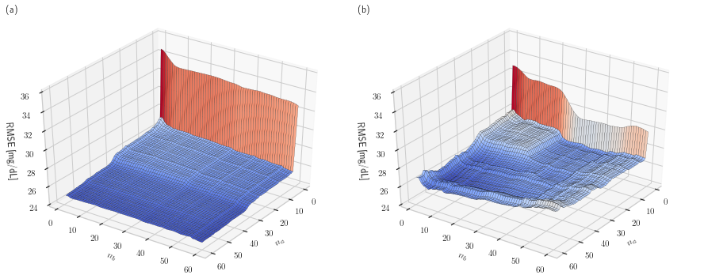

```python
# Generamos la figura y axis
fig = plt.figure()
ax1 = fig.add_subplot(1, 2, 1, projection='3d')
ax2 = fig.add_subplot(1, 2, 2, projection='3d')

# Generamos el conjunto para graficar
X = RMSE_test_meal.index
Y = RMSE_test_meal.columns
X, Y = np.meshgrid(X, Y)

# Graficamos
surf1 = ax1.plot_surface(Y, X, RMSE_train_meal, cmap=cm.coolwarm, linewidth=0.2, rstride=1, cstride=1, edgecolors='k')
surf2 = ax2.plot_surface(Y, X, RMSE_test_meal, cmap=cm.coolwarm, linewidth=0.2, rstride=1, cstride=1, edgecolors='k')

# Parametros
ax1.view_init(35, 35)
ax2.view_init(35, 35)
ax1.set_xlabel(r'$n_a$')
ax2.set_xlabel(r'$n_a$')
ax1.set_ylabel(r'$n_b$')
ax2.set_ylabel(r'$n_b$')
ax1.set_zlabel('RMSE [mg/dL]')
ax2.set_zlabel('RMSE [mg/dL]')
ax1.set_zlim(24,36)
ax2.set_zlim(24,36)
ax1.set_title('(a)', loc='left')
ax2.set_title('(b)', loc='left')

y_size = 5
x_size = 2.5 * y_size
fig.set_size_inches(x_size, y_size)
plt.tight_layout()
format_name = 'figs/RMSE_meal'
fig.savefig(format_name + '.svg')
fig.savefig(format_name + '.pdf')
```

- Gráfico para bolos:

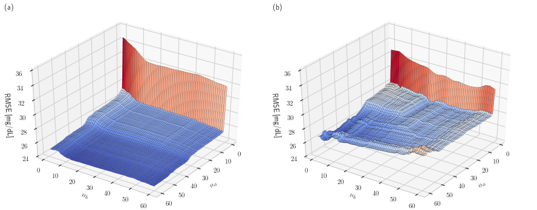

```python
# Generamos la figura y axis
fig = plt.figure()
ax1 = fig.add_subplot(1, 2, 1, projection='3d')
ax2 = fig.add_subplot(1, 2, 2, projection='3d')

# Generamos el conjunto para graficar
X = RMSE_test_meal.index
Y = RMSE_test_meal.columns
X, Y = np.meshgrid(X, Y)

# Graficamos
surf1 = ax1.plot_surface(Y, X, RMSE_train_bolo, cmap=cm.coolwarm, linewidth=0.2, rstride=1, cstride=1, edgecolors='k')
surf2 = ax2.plot_surface(Y, X, RMSE_test_bolo, cmap=cm.coolwarm, linewidth=0.2, rstride=1, cstride=1, edgecolors='k')

# Parametros
ax1.view_init(35, 35)
ax2.view_init(35, 35)
ax1.set_xlabel(r'$n_a$')
ax2.set_xlabel(r'$n_a$')
ax1.set_ylabel(r'$n_b$')
ax2.set_ylabel(r'$n_b$')
ax1.set_zlabel('RMSE [mg/dL]')
ax2.set_zlabel('RMSE [mg/dL]')
ax1.set_zlim(24,36)
ax2.set_zlim(24,36)
ax1.set_title('(a)', loc='left')
ax2.set_title('(b)', loc='left')

y_size = 5
x_size = 2.5 * y_size
fig.set_size_inches(x_size, y_size)
plt.tight_layout()
format_name = 'figs/RMSE_bolo'
fig.savefig(format_name + '.svg')
fig.savefig(format_name + '.pdf')
```

```python
min_RMSE_bolo = RMSE_test_bolo.to_numpy()
min_RMSE_meal = RMSE_test_meal.to_numpy()

[n_a, n_b] = np.where(min_RMSE_meal == np.amin(min_RMSE_meal))
n_a_meal = int(n_a) + 1
n_b_meal = int(n_b) + 1

[n_a, n_b] = np.where(min_RMSE_bolo == np.amin(min_RMSE_bolo))
n_a_bolo = int(n_a) + 1
n_b_bolo = int(n_b) + 1

print('Orden optimo para ARX con meal:')
print(' - n_a = {}, n_b = {}'.format(n_a_meal, n_b_meal))
print(' - RMSE_train = {}'.format(RMSE_train_meal.iloc[n_a_meal-1, n_b_meal-1]))
print(' - RMSE_test = {}'.format(RMSE_test_meal.iloc[n_a_meal-1, n_b_meal-1]))
print('Orden optimo para ARX con bolo:')
print(' - n_a = {}, n_b = {}'.format(n_a_bolo, n_b_bolo))
print(' - RMSE_train = {}'.format(RMSE_train_bolo.iloc[n_a_bolo-1, n_b_bolo-1]))
print(' - RMSE_test = {}'.format(RMSE_train_bolo.iloc[n_a_bolo-1, n_b_bolo-1]))
```

```
Orden optimo para ARX con meal:
 - n_a = 48, n_b = 6
 - RMSE_train = 25.147
 - RMSE_test = 25.421999999999997
Orden optimo para ARX con bolo:
 - n_a = 48, n_b = 4
 - RMSE_train = 25.371
 - RMSE_test = 25.371
```

## 4.4 Modelo óptimo para meal

Utilizando MATLAB, se buscó el óptimo y se extrajeron los parámetros. Estos se guardaron en un archivo `.csv`. Se utilizó la convención en la documentación de MATLAB para crear la función.

```python
# Orden del modelo
n_a = 48
n_b = 6

# Valor de los vectores del polinomio A(q) y B(q)
A = np.genfromtxt('A_meal.csv', delimiter=',')
B = np.genfromtxt('B_meal.csv', delimiter=',')

# Generamos el modelo
def arx_meal_model(z):
    global A, B
    x = z[-len(A) + 1:]
    phi_A = np.flip(-A[1:])
    u = z[:len(B)]

    phi_B = np.flip(B)
    sum_A = np.inner(phi_A, x)
    sum_B = np.inner(phi_B, u)
    return sum_A + sum_B
```

Con el modelo entrenado, comenzamos a analizar el modelo

```python
# pasos a predecir
k = 6

######################################
# Dataframe para predecir
######################################
u_train = copy.copy(data_train['u_meal'])
Z_train = pd.DataFrame(copy.copy(data_train['y']))
u_test = copy.copy(data_test['u_meal'])
Z_test = pd.DataFrame(copy.copy(data_test['y']))

# Agregamos la variable endogena
for i in range(n_a - 1):
    Z_train['y-{}'.format(i+1)] = Z_train['y'].shift(i+1)
    Z_test['y-{}'.format(i+1)] = Z_test['y'].shift(i+1)

# Agregamos la variable exogena
Z_train['u_meal'] = u_train
Z_test['u_meal'] = u_test
for i in range(n_b):
    Z_train['u_meal-{}'.format(i+1)] = u_train.shift(i+1)
    Z_test['u_meal-{}'.format(i+1)] = u_test.shift(i+1)
Z_train = Z_train[Z_train.columns[::-1]]
Z_test = Z_test[Z_test.columns[::-1]]

######################################
# Prediccion
######################################
# Realizamos la prediccion
for i in range(k):
    Z_train['y+{}'.format(i+1)] = Z_train.apply(arx_meal_model, axis=1)
    Z_test['y+{}'.format(i+1)] = Z_test.apply(arx_meal_model, axis=1)

# Se debe desfasar la prediccion para que coincida con el valor el tiempo
for i in range(k):
    Z_train['y+{}'.format(i+1)] = Z_train['y+{}'.format(i+1)].shift(i+1)
    Z_test['y+{}'.format(i+1)] = Z_test['y+{}'.format(i+1)].shift(i+1)

######################################
# Calculo de los errores
######################################

# 1 paso adelante (5 minutos)
Z_train['e_1_paso'] = Z_train['y+1'] - Z_train['y']
Z_test['e_1_paso'] = Z_test['y+1'] - Z_test['y']

# 6 pasos adelante (30 minutos)
Z_train['e_6_paso'] = Z_train['y+6'] - Z_train['y']
Z_test['e_6_paso'] = Z_test['y+6'] - Z_test['y']

# Trayectoria (5 a 30 minutos)
Z_train['e_trajec'] = Z_train.apply(error_trayectoria, axis=1)
Z_test['e_trajec'] = Z_test.apply(error_trayectoria, axis=1)
```

### Análisis estadístico del error

```python
Z_train[['e_1_paso', 'e_6_paso', 'e_trajec']].describe()
```

|  | e_1_paso | e_6_paso | e_trajec |
| --- | --- | --- | --- |
| count | 1104.000000 | 1099.000000 | 1099.000000 |
| mean | -0.101903 | -1.670706 | 13.226789 |
| std | 3.611811 | 26.573128 | 10.300007 |
| min | -33.369798 | -103.347627 | 1.415856 |
| 25% | -1.885061 | -15.883502 | 5.988798 |
| 50% | -0.110922 | -3.477389 | 10.095220 |
| 75% | 1.552751 | 10.632791 | 17.180102 |
| max | 23.290998 | 138.500676 | 79.774232 |

```python
Z_test[['e_1_paso', 'e_6_paso', 'e_trajec']].describe()
```

|  | e_1_paso | e_6_paso | e_trajec |
| --- | --- | --- | --- |
| count | 528.000000 | 523.000000 | 523.000000 |
| mean | -0.143038 | -2.090588 | 14.694924 |
| std | 4.237913 | 27.026938 | 9.920583 |
| min | -18.775284 | -90.745996 | 0.999464 |
| 25% | -2.175485 | -18.849115 | 7.155240 |
| 50% | -0.390544 | -2.308722 | 12.087453 |
| 75% | 1.681438 | 12.271713 | 19.763279 |
| max | 18.239200 | 104.231599 | 60.408372 |

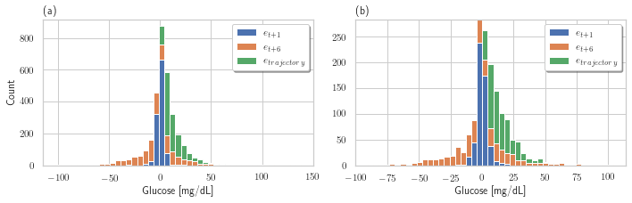

```python
# Creamos la figura
fig, (ax1, ax2) = plt.subplots(1, 2)

#Parametros del grafico
data1 = [Z_train['e_1_paso'].dropna(), Z_train['e_6_paso'].dropna(), Z_train['e_trajec'].dropna()]
data2 = [Z_test['e_1_paso'].dropna(), Z_test['e_6_paso'].dropna(), Z_test['e_trajec'].dropna()]
colors = ['C0', 'C1', 'C2']
n_bins = 45
labels = ['$e_{t+1}$', '$e_{t+6}$', '$e_{trajectory}$']

# Realizamos el histograma
ax1.hist(data1, color=colors, bins=n_bins, label=labels, stacked=True)
ax2.hist(data2, color=colors, bins=n_bins, label=labels, stacked=True)

# Configuraciones
ax1.grid(True)
ax2.grid(True)
ax1.set_ylabel('Count')
ax1.set_xlabel('Glucose [mg/dL]')
ax2.set_xlabel('Glucose [mg/dL]')
ax1.legend(fancybox=True, shadow=True)
ax2.legend(fancybox=True, shadow=True)
ax1.set_title('(a)', loc='left')
ax2.set_title('(b)', loc='left')


x_size = 10
y_size = x_size / 3
fig.set_size_inches(x_size, y_size)
plt.tight_layout()
format_name = 'figs/error_histograma_na_48_nb_6_meal'
fig.savefig(format_name + '.svg')
fig.savefig(format_name + '.pdf')
```

### Cálculo de indicadores de desempeño

```python
# Extraemos los vectores de los errores
e1 = copy.copy(Z_train['e_1_paso'])
e6 = copy.copy(Z_train['e_6_paso'])
ee = copy.copy(Z_train['e_trajec'])
# Eliminamos los puntos los nan
e1.dropna(inplace=True)
e6.dropna(inplace=True)
ee.dropna(inplace=True)
# Calculamos el resultado
RMSE_1_paso = np.sqrt(sum(e1 ** 2) / len(e1))
RMSE_6_paso = np.sqrt(sum(e6 ** 2) / len(e6))
RMSE_trajec = np.sqrt(sum(ee ** 2) / len(ee))
# Lo desplegamos por consola
print(' - Training')
print('RMSE 1 paso : {:.3f}'.format(RMSE_1_paso))
print('RMSE 6 pasos: {:.3f}'.format(RMSE_6_paso))
print('RMSE traject: {:.3f}'.format(RMSE_trajec))
```

```
 - Training
RMSE 1 paso : 3.612
RMSE 6 pasos: 26.614
RMSE traject: 16.761
```

```python
# Extraemos los vectores de los errores
e1 = copy.copy(Z_test['e_1_paso'])
e6 = copy.copy(Z_test['e_6_paso'])
ee = copy.copy(Z_test['e_trajec'])
# Eliminamos los puntos los nan
e1.dropna(inplace=True)
e6.dropna(inplace=True)
ee.dropna(inplace=True)
# Calculamos el resultado
RMSE_1_paso = np.sqrt(sum(e1 ** 2) / len(e1))
RMSE_6_paso = np.sqrt(sum(e6 ** 2) / len(e6))
RMSE_trajec = np.sqrt(sum(ee ** 2) / len(ee))
# Lo desplegamos por consola
print(' - Testing')
print('RMSE 1 paso : {:.3f}'.format(RMSE_1_paso))
print('RMSE 6 pasos: {:.3f}'.format(RMSE_6_paso))
print('RMSE traject: {:.3f}'.format(RMSE_trajec))
```

```
 - Testing
RMSE 1 paso : 4.236
RMSE 6 pasos: 27.082
RMSE traject: 17.725
```

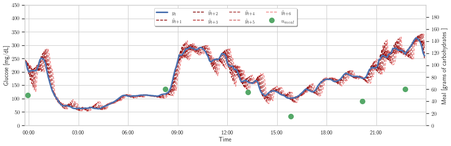

```python
# Parametros
f_ini = pd.Timestamp('2020-01-28 23:45:00')
f_fin = pd.Timestamp('2020-01-29 23:59:59')

# Graficamos
fig, ax = plt.subplots()

ax.plot(Z_test['y+6'][f_ini: f_fin], color='lightcoral',
        linestyle='--', label='$\hat{y}_{t + 6}$')
ax.plot(Z_test['y+5'][f_ini: f_fin], color='indianred',
        linestyle='--', label='$\hat{y}_{t + 5}$')
ax.plot(Z_test['y+4'][f_ini: f_fin], color='brown',
        linestyle='--', label='$\hat{y}_{t + 4}$')
ax.plot(Z_test['y+3'][f_ini: f_fin], color='firebrick',
        linestyle='--', label='$\hat{y}_{t + 3}$')
ax.plot(Z_test['y+2'][f_ini: f_fin], color='maroon',
        linestyle='--', label='$\hat{y}_{t + 2}$')
ax.plot(Z_test['y+1'][f_ini: f_fin], color='darkred',
        linestyle='--', label='$\hat{y}_{t + 1}$')
ax.plot(Z_test['y'][f_ini: f_fin], color='C0', linewidth=3.0
       , label='$y_{t}$')

# Grafico de meal
l1 = ax2 = ax.twinx()
ax2.plot(Z_test['u_meal'][f_ini: f_fin].replace(0, np.nan).dropna(), marker='o', color='C2',
         label='$u_{meal}$', linestyle='None', markersize='10')
# parametros del grafico 2
ax2.grid(False)
ax2.tick_params(rotation=0)
ax2.set_ylim([0, 200])
ax2.set_yticks(np.arange(0, 200, 20))
ax2.tick_params(axis='y', pad=5)
ax2.set_ylabel('Meal [grams of carbohydrates ]')

# Parametros del grafico 1
ax.grid(True)
ax.set_ylim([0, 450])
ax.set_xlim([f_ini, f_fin])
ax.set_ylabel('Glucose [mg/dL]')
ax.set_xlabel('Time')

# leyenda
handles1, labels1 = ax.get_legend_handles_labels()
handles2, labels2 = ax2.get_legend_handles_labels()
handles = handles2 + handles1
labels = labels2 + labels1
handles.reverse()
labels.reverse()
ax.legend(handles, labels, loc= 'upper center', ncol=4, fancybox=True, shadow=True)

# Formato de las fechas
date_form = mdates.DateFormatter('%H:%M')
ax.xaxis.set_major_formatter(date_form)

y_size = 4.2
x_size = 3 * y_size
fig.set_size_inches(x_size, y_size)
plt.tight_layout()

format_name = 'figs/grafico_tiempo_na_48_nb_6_1_meal'
fig.savefig(format_name + '.svg')
fig.savefig(format_name + '.pdf')
```

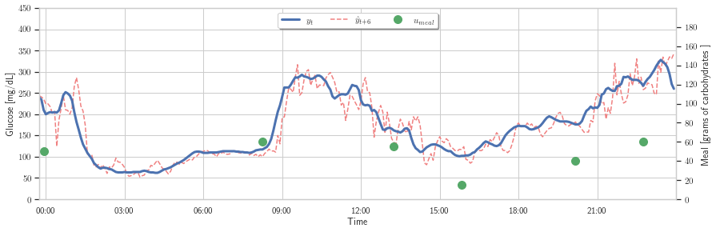

```python
# Parametros
f_ini = pd.Timestamp('2020-01-28 23:45:00')
f_fin = pd.Timestamp('2020-01-29 23:59:59')

# Graficamos
fig, ax = plt.subplots()

ax.plot(Z_test['y+6'][f_ini: f_fin], color='lightcoral',
        linestyle='--', label='$\hat{y}_{t + 6}$')
ax.plot(Z_test['y'][f_ini: f_fin], color='C0', linewidth=3.0
       , label='$y_{t}$')

# Grafico de meal
l1 = ax2 = ax.twinx()
ax2.plot(Z_test['u_meal'][f_ini: f_fin].replace(0, np.nan).dropna(), marker='o', color='C2',
         label='$u_{meal}$', linestyle='None', markersize='10')
# parametros del grafico 2
ax2.grid(False)
ax2.tick_params(rotation=0)
ax2.set_ylim([0, 200])
ax2.set_yticks(np.arange(0, 200, 20))
ax2.tick_params(axis='y', pad=5)
ax2.set_ylabel('Meal [grams of carbohydrates ]')

# Parametros del grafico 1
ax.grid(True)
ax.set_ylim([0, 450])
ax.set_xlim([f_ini, f_fin])
ax.set_ylabel('Glucose [mg/dL]')
ax.set_xlabel('Time')

# leyenda
handles1, labels1 = ax.get_legend_handles_labels()
handles2, labels2 = ax2.get_legend_handles_labels()
handles = handles2 + handles1
labels = labels2 + labels1
handles.reverse()
labels.reverse()
ax.legend(handles, labels, loc= 'upper center', ncol=4, fancybox=True, shadow=True)

# Formato de las fechas
date_form = mdates.DateFormatter('%H:%M')
ax.xaxis.set_major_formatter(date_form)

y_size = 4.2
x_size = 3 * y_size
fig.set_size_inches(x_size, y_size)
plt.tight_layout()

format_name = 'figs/grafico_tiempo_na_48_nb_6_2_meal'
fig.savefig(format_name + '.svg')
fig.savefig(format_name + '.pdf')
```

### Gráfico del error

- Graficamos el error del training

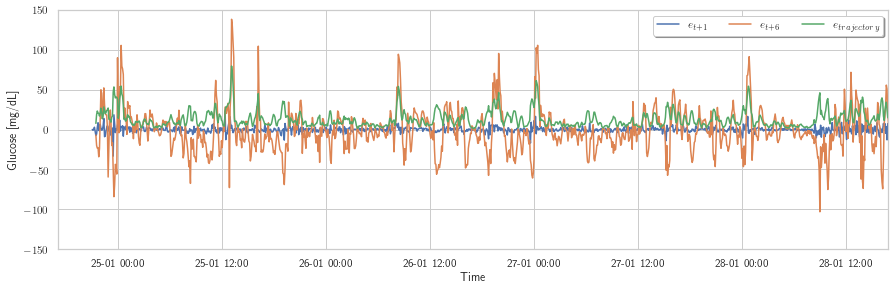

```python
# Parametros
f_ini = Z_train.index[0]
f_fin = Z_train.index[-1]

# Graficamos
fig, ax = plt.subplots()

ax.plot(Z_train['e_1_paso'][f_ini: f_fin], color='C0', linestyle='-', label='$e_{t + 1}$')
ax.plot(Z_train['e_6_paso'][f_ini: f_fin], color='C1', linestyle='-', label='$e_{t + 6}$')
ax.plot(Z_train['e_trajec'][f_ini: f_fin], color='C2', linestyle='-', label='$e_{trajectory}$')

# Parametros
ax.grid(True)
ax.set_ylim([-150, 150])
ax.set_xlim([f_ini, f_fin])
ax.set_ylabel('Glucose [mg/dL]')
ax.set_xlabel('Time')

# leyenda
ax.legend(ncol=4, fancybox=True, shadow=True)

# Formato de las fechas
date_form = mdates.DateFormatter('%d-%m %H:%M')
ax.xaxis.set_major_formatter(date_form)

y_size = 4.2
x_size = 3 * y_size
fig.set_size_inches(x_size, y_size)
plt.tight_layout()

format_name = 'figs/error_grafico_training_na_48_nb_6_meal'
fig.savefig(format_name + '.svg')
fig.savefig(format_name + '.pdf')
```

- Graficamos el error del testing

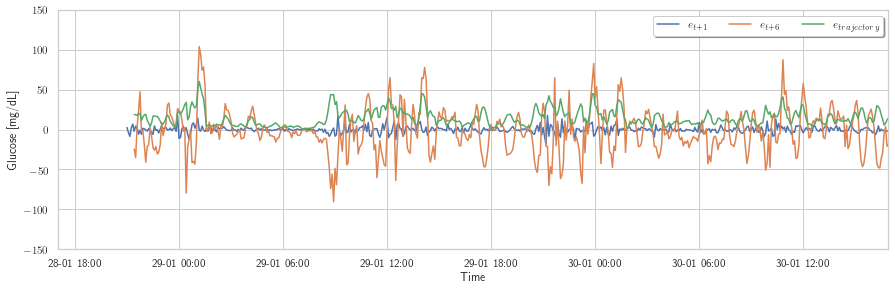

```python
# Parametros
f_ini = Z_test.index[0]
f_fin = Z_test.index[-1]

# Graficamos
fig, ax = plt.subplots()

ax.plot(Z_test['e_1_paso'][f_ini: f_fin], color='C0', linestyle='-', label='$e_{t + 1}$')
ax.plot(Z_test['e_6_paso'][f_ini: f_fin], color='C1', linestyle='-', label='$e_{t + 6}$')
ax.plot(Z_test['e_trajec'][f_ini: f_fin], color='C2', linestyle='-', label='$e_{trajectory}$')

# Parametros
ax.grid(True)
ax.set_ylim([-150, 150])
ax.set_xlim([f_ini, f_fin])
ax.set_ylabel('Glucose [mg/dL]')
ax.set_xlabel('Time')

# leyenda
ax.legend(ncol=4, fancybox=True, shadow=True)

# Formato de las fechas
date_form = mdates.DateFormatter('%d-%m %H:%M')
ax.xaxis.set_major_formatter(date_form)

y_size = 4.2
x_size = 3 * y_size
fig.set_size_inches(x_size, y_size)
plt.tight_layout()

format_name = 'figs/error_grafico_testing_na_48_nb_6_meal'
fig.savefig(format_name + '.svg')
fig.savefig(format_name + '.pdf')
```

### Análisis en frecuencia del error

- Periodograma para el training

```python
e1 = Z_train['e_1_paso'].dropna()
N = len(e1)
freq = fftfreq(N, 5*60)
E1 = fft(e1, norm='ortho')
E1_N = abs(E1) ** 2
E1_N = pd.Series(E1_N, index=freq)
E1_N = E1_N[freq > 0]

e6 = Z_train['e_6_paso'].dropna()
N = len(e6)
freq = fftfreq(N, 5*60)
E6 = fft(e6, norm='ortho')
E6_N = abs(E6) ** 2
E6_N = pd.Series(E6_N, index=freq)
E6_N = E6_N[freq > 0]

ee = Z_train['e_trajec'].dropna()
N = len(ee)
freq = fftfreq(N, 5*60)
EE = fft(ee, norm='ortho')
EE_N = abs(EE) ** 2
EE_N = pd.Series(EE_N, index=freq)
EE_N = EE_N[freq > 0]
```

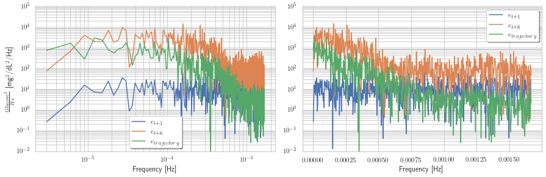

```python
# Creamos la figura y el axis
fig, (ax1, ax2) = plt.subplots(1, 2)

# Realizamos el grafico
ax1.loglog(E1_N, color='C0', label=r'$e_{t+1}$')
ax1.loglog(E6_N, color='C1', label=r'$e_{t+6}$')
ax1.loglog(EE_N, color='C2', label=r'$e_{trajectory}$')

ax2.semilogy(E1_N, color='C0', label=r'$e_{t+1}$')
ax2.semilogy(E6_N, color='C1', label=r'$e_{t+6}$')
ax2.semilogy(EE_N, color='C2', label=r'$e_{trajectory}$')

# Configuramos los parametros
ax1.grid(True, which='both')
ax1.set_ylim([10 ** (-2), 10 ** 5])
ax1.legend(fancybox=True, shadow=True)

ax2.grid(True, which='both')
ax2.set_ylim([10 ** (-2), 10 ** 5])
ax2.legend(fancybox=True, shadow=True)

ax1.set_ylabel(r'$\frac{Glucose^2}{Hz}$ [mg$^2$/dL$^2$/Hz]')
ax1.set_xlabel(r'Frequency [Hz]')
ax2.set_xlabel(r'Frequency [Hz]')

x_size = 3 * 4.2
y_size = 1 * x_size / 3
fig.set_size_inches(x_size, y_size)
plt.tight_layout()

format_name = 'figs/error_periodograma_training_na_48_nb_6_meal'
fig.savefig(format_name + '.svg')
fig.savefig(format_name + '.pdf')
```

- Periodograma para el testing

```python
e1 = Z_test['e_1_paso'].dropna()
N = len(e1)
freq = fftfreq(N, 5*60)
E1 = fft(e1, norm='ortho')
E1_N = abs(E1) ** 2
E1_N = pd.Series(E1_N, index=freq)
E1_N = E1_N[freq > 0]

e6 = Z_test['e_6_paso'].dropna()
N = len(e6)
freq = fftfreq(N, 5*60)
E6 = fft(e6, norm='ortho')
E6_N = abs(E6) ** 2
E6_N = pd.Series(E6_N, index=freq)
E6_N = E6_N[freq > 0]

ee = Z_test['e_trajec'].dropna()
N = len(ee)
freq = fftfreq(N, 5*60)
EE = fft(ee, norm='ortho')
EE_N = abs(EE) ** 2
EE_N = pd.Series(EE_N, index=freq)
EE_N = EE_N[freq > 0]
```

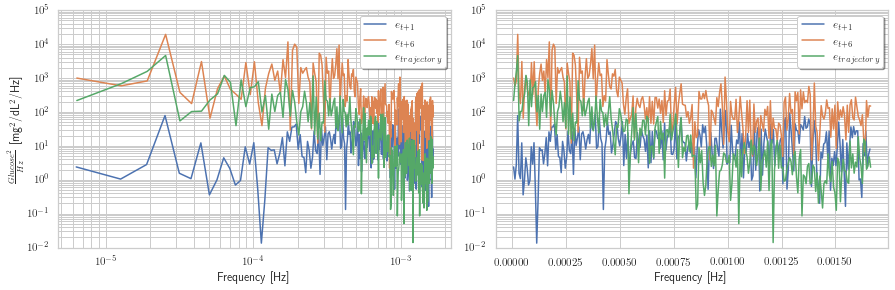

```python
# Creamos la figura y el axis
fig, (ax1, ax2) = plt.subplots(1, 2)

# Realizamos el grafico
ax1.loglog(E1_N, color='C0', label=r'$e_{t+1}$')
ax1.loglog(E6_N, color='C1', label=r'$e_{t+6}$')
ax1.loglog(EE_N, color='C2', label=r'$e_{trajectory}$')

ax2.semilogy(E1_N, color='C0', label=r'$e_{t+1}$')
ax2.semilogy(E6_N, color='C1', label=r'$e_{t+6}$')
ax2.semilogy(EE_N, color='C2', label=r'$e_{trajectory}$')

# Configuramos los parametros
ax1.grid(True, which='both')
ax1.set_ylim([10 ** (-2), 10 ** 5])
ax1.legend(fancybox=True, shadow=True)

ax2.grid(True, which='both')
ax2.set_ylim([10 ** (-2), 10 ** 5])
ax2.legend(fancybox=True, shadow=True)

ax1.set_ylabel(r'$\frac{Glucose^2}{Hz}$ [mg$^2$/dL$^2$/Hz]')
ax1.set_xlabel(r'Frequency [Hz]')
ax2.set_xlabel(r'Frequency [Hz]')

x_size = 3 * 4.2
y_size = 1 * x_size / 3
fig.set_size_inches(x_size, y_size)
plt.tight_layout()

format_name = 'figs/error_periodograma_testing_na_48_nb=6_meal'
fig.savefig(format_name + '.svg')
fig.savefig(format_name + '.pdf')
```

- Espectro para el training

```python
e1 = Z_train['e_1_paso'].dropna()
e6 = Z_train['e_6_paso'].dropna()
ee = Z_train['e_trajec'].dropna()

R_e1 = np.correlate(e1, e1, mode='full') / N
R_e6 = np.correlate(e6, e6, mode='full') / N
R_ee = np.correlate(ee, ee, mode='full') / N

N1 = len(R_e1)
N6 = len(R_e6)
Ne = len(R_ee)

# Gamma = N/2
gamma = round(N1 / 2) - 1
phi_E1 = phi_X(R_e1, gamma)

gamma = round(N6 / 2) - 1
phi_E6 = phi_X(R_e6, gamma)

gamma = round(Ne / 2) - 1
phi_EE = phi_X(R_ee, gamma)
```

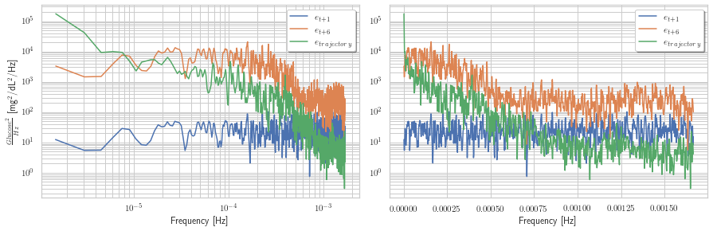

```python
# Creamos la figura y el axis
fig, (ax1, ax2) = plt.subplots(1, 2)

# Realizamos el grafico
ax1.loglog(abs(phi_E1), color='C0', label=r'$e_{t+1}$')
ax1.loglog(abs(phi_E6), color='C1', label=r'$e_{t+6}$')
ax1.loglog(abs(phi_EE), color='C2', label=r'$e_{trajectory}$')

ax2.semilogy(abs(phi_E1), color='C0', label=r'$e_{t+1}$')
ax2.semilogy(abs(phi_E6), color='C1', label=r'$e_{t+6}$')
ax2.semilogy(abs(phi_EE), color='C2', label=r'$e_{trajectory}$')

# Configuramos los parametros
ax1.grid(True, which='both')
#ax1.set_ylim([10 ** (-2), 10 ** 6])
#ax1.set_xlim([10 ** (-6), max(Y_N.index)])
ax1.legend(fancybox=True, shadow=True)

ax2.grid(True, which='both')
#ax2.set_ylim([10 ** (-2), 10 ** 6])
#ax2.set_xlim([10 ** (-6), max(Y_N.index)])
ax2.legend(fancybox=True, shadow=True)

ax1.set_ylabel(r'$\frac{Glucose^2}{Hz}$ [mg$^2$/dL$^2$/Hz]')
ax1.set_xlabel(r'Frequency [Hz]')
ax2.set_xlabel(r'Frequency [Hz]')

x_size = 3 * 4.2
y_size = 1 * x_size / 3
fig.set_size_inches(x_size, y_size)
plt.tight_layout()

format_name = 'figs/error_espectro_training_na_48_nb_6_meal'
fig.savefig(format_name + '.svg')
fig.savefig(format_name + '.pdf')
```

- Espectro para el testing

```python
e1 = Z_test['e_1_paso'].dropna()
e6 = Z_test['e_6_paso'].dropna()
ee = Z_test['e_trajec'].dropna()

R_e1 = np.correlate(e1, e1, mode='full') / N
R_e6 = np.correlate(e6, e6, mode='full') / N
R_ee = np.correlate(ee, ee, mode='full') / N

N1 = len(R_e1)
N6 = len(R_e6)
Ne = len(R_ee)

# Gamma = N/2
gamma = round(N1 / 2) - 1
phi_E1 = phi_X(R_e1, gamma)

gamma = round(N6 / 2) - 1
phi_E6 = phi_X(R_e6, gamma)

gamma = round(Ne / 2) - 1
phi_EE = phi_X(R_ee, gamma)
```

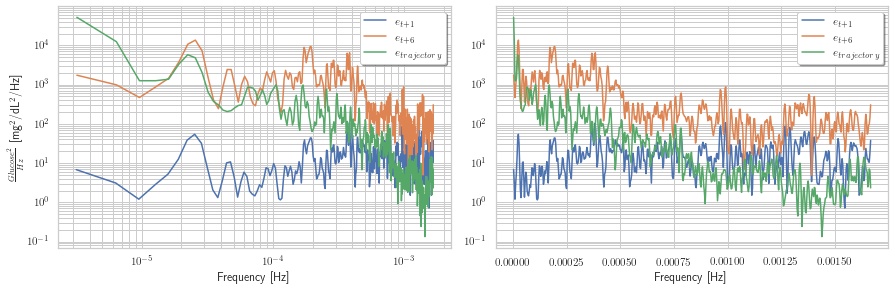

```python
# Creamos la figura y el axis
fig, (ax1, ax2) = plt.subplots(1, 2)

# Realizamos el grafico
ax1.loglog(abs(phi_E1), color='C0', label=r'$e_{t+1}$')
ax1.loglog(abs(phi_E6), color='C1', label=r'$e_{t+6}$')
ax1.loglog(abs(phi_EE), color='C2', label=r'$e_{trajectory}$')

ax2.semilogy(abs(phi_E1), color='C0', label=r'$e_{t+1}$')
ax2.semilogy(abs(phi_E6), color='C1', label=r'$e_{t+6}$')
ax2.semilogy(abs(phi_EE), color='C2', label=r'$e_{trajectory}$')

# Configuramos los parametros
ax1.grid(True, which='both')
#ax1.set_ylim([10 ** (-2), 10 ** 6])
#ax1.set_xlim([10 ** (-6), max(Y_N.index)])
ax1.legend(fancybox=True, shadow=True)

ax2.grid(True, which='both')
#ax2.set_ylim([10 ** (-2), 10 ** 6])
#ax2.set_xlim([10 ** (-6), max(Y_N.index)])
ax2.legend(fancybox=True, shadow=True)

ax1.set_ylabel(r'$\frac{Glucose^2}{Hz}$ [mg$^2$/dL$^2$/Hz]')
ax1.set_xlabel(r'Frequency [Hz]')
ax2.set_xlabel(r'Frequency [Hz]')

x_size = 3 * 4.2
y_size = 1 * x_size / 3
fig.set_size_inches(x_size, y_size)
plt.tight_layout()

format_name = 'figs/error_espectro_testing_na_48_nb_6_meal'
fig.savefig(format_name + '.svg')
fig.savefig(format_name + '.pdf')
```

## 4.5 Modelo optimo para bolo de insulina

```python
# Orden del modelo
n_a = 48
n_b = 4

# Valor de los vectores del polinomio A(q) y B(q)
A = np.genfromtxt('A_bolo.csv', delimiter=',')
B = np.genfromtxt('B_bolo.csv', delimiter=',')

# Generamos el modelo
def arx_meal_model(z):
    global A, B
    x = z[-len(A) + 1:]
    phi_A = np.flip(-A[1:])
    u = z[:len(B)]

    phi_B = np.flip(B)
    sum_A = np.inner(phi_A, x)
    sum_B = np.inner(phi_B, u)
    return sum_A + sum_B
```

Con el modelo entrenado, comenzamos a analizaar el modelo

```python
# pasos a predecir
k = 6

######################################
# Dataframe para predecir
######################################
u_train = copy.copy(data_train['u_bolo'])
Z_train = pd.DataFrame(copy.copy(data_train['y']))
u_test = copy.copy(data_test['u_bolo'])
Z_test = pd.DataFrame(copy.copy(data_test['y']))

# Agregamos la variable endogena
for i in range(n_a - 1):
    Z_train['y-{}'.format(i+1)] = Z_train['y'].shift(i+1)
    Z_test['y-{}'.format(i+1)] = Z_test['y'].shift(i+1)

# Agregamos la variable exogena
Z_train['u_bolo'] = u_train
Z_test['u_bolo'] = u_test
for i in range(n_b):
    Z_train['u_bolo-{}'.format(i+1)] = u_train.shift(i+1)
    Z_test['u_bolo-{}'.format(i+1)] = u_test.shift(i+1)
Z_train = Z_train[Z_train.columns[::-1]]
Z_test = Z_test[Z_test.columns[::-1]]

######################################
# Prediccion
######################################
# Realizamos la prediccion
for i in range(k):
    Z_train['y+{}'.format(i+1)] = Z_train.apply(arx_meal_model, axis=1)
    Z_test['y+{}'.format(i+1)] = Z_test.apply(arx_meal_model, axis=1)

# Se debe desfasar la prediccion para que coincida con el valor el tiempo
for i in range(k):
    Z_train['y+{}'.format(i+1)] = Z_train['y+{}'.format(i+1)].shift(i+1)
    Z_test['y+{}'.format(i+1)] = Z_test['y+{}'.format(i+1)].shift(i+1)

######################################
# Calculo de los errores
######################################

# 1 paso adelante (5 minutos)
Z_train['e_1_paso'] = Z_train['y+1'] - Z_train['y']
Z_test['e_1_paso'] = Z_test['y+1'] - Z_test['y']

# 6 pasos adelante (30 minutos)
Z_train['e_6_paso'] = Z_train['y+6'] - Z_train['y']
Z_test['e_6_paso'] = Z_test['y+6'] - Z_test['y']

# Trayectoria (5 a 30 minutos)
Z_train['e_trajec'] = Z_train.apply(error_trayectoria, axis=1)
Z_test['e_trajec'] = Z_test.apply(error_trayectoria, axis=1)
```

### Análisis estadístico del error

```python
Z_train[['e_1_paso', 'e_6_paso', 'e_trajec']].describe()
```

|  | e_1_paso | e_6_paso | e_trajec |
| --- | --- | --- | --- |
| count | 1104.000000 | 1099.000000 | 1099.000000 |
| mean | -0.101721 | -1.734201 | 13.471651 |
| std | 3.630354 | 27.123656 | 10.446365 |
| min | -33.453266 | -111.312857 | 1.419129 |
| 25% | -1.919838 | -15.932259 | 6.049140 |
| 50% | -0.043859 | -3.042082 | 10.303623 |
| 75% | 1.552926 | 11.515462 | 17.727656 |
| max | 23.343764 | 127.386559 | 73.957902 |

```python
Z_test[['e_1_paso', 'e_6_paso', 'e_trajec']].describe()
```

|  | e_1_paso | e_6_paso | e_trajec |
| --- | --- | --- | --- |
| count | 528.000000 | 523.000000 | 523.000000 |
| mean | -0.140248 | -2.074435 | 14.983858 |
| std | 4.256432 | 27.525152 | 10.004308 |
| min | -18.661382 | -97.855223 | 1.005484 |
| 25% | -2.310548 | -18.146346 | 7.410061 |
| 50% | -0.355925 | -3.042706 | 12.614663 |
| 75% | 1.785272 | 13.141909 | 20.042113 |
| max | 18.146178 | 104.019138 | 60.024916 |

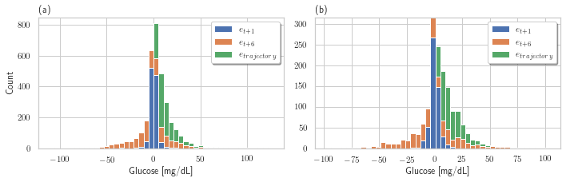

```python
# Creamos la figura
fig, (ax1, ax2) = plt.subplots(1, 2)

#Parametros del grafico
data1 = [Z_train['e_1_paso'].dropna(), Z_train['e_6_paso'].dropna(), Z_train['e_trajec'].dropna()]
data2 = [Z_test['e_1_paso'].dropna(), Z_test['e_6_paso'].dropna(), Z_test['e_trajec'].dropna()]
colors = ['C0', 'C1', 'C2']
n_bins = 45
labels = ['$e_{t+1}$', '$e_{t+6}$', '$e_{trajectory}$']

# Realizamos el histograma
ax1.hist(data1, color=colors, bins=n_bins, label=labels, stacked=True)
ax2.hist(data2, color=colors, bins=n_bins, label=labels, stacked=True)

# Configuraciones
ax1.grid(True)
ax2.grid(True)
ax1.set_ylabel('Count')
ax1.set_xlabel('Glucose [mg/dL]')
ax2.set_xlabel('Glucose [mg/dL]')
ax1.legend(fancybox=True, shadow=True)
ax2.legend(fancybox=True, shadow=True)
ax1.set_title('(a)', loc='left')
ax2.set_title('(b)', loc='left')


x_size = 10
y_size = x_size / 3
fig.set_size_inches(x_size, y_size)
plt.tight_layout()
format_name = 'figs/error_histograma_na_48_nb_4_bolo'
fig.savefig(format_name + '.svg')
fig.savefig(format_name + '.pdf')
```

### Cálculo de indicadores de desempeño

```python
# Extraemos los vectores de los errores
e1 = copy.copy(Z_train['e_1_paso'])
e6 = copy.copy(Z_train['e_6_paso'])
ee = copy.copy(Z_train['e_trajec'])
# Eliminamos los puntos los nan
e1.dropna(inplace=True)
e6.dropna(inplace=True)
ee.dropna(inplace=True)
# Calculamos el resultado
RMSE_1_paso = np.sqrt(sum(e1 ** 2) / len(e1))
RMSE_6_paso = np.sqrt(sum(e6 ** 2) / len(e6))
RMSE_trajec = np.sqrt(sum(ee ** 2) / len(ee))
# Lo desplegamos por consola
print(' - Training')
print('RMSE 1 paso : {:.3f}'.format(RMSE_1_paso))
print('RMSE 6 pasos: {:.3f}'.format(RMSE_6_paso))
print('RMSE traject: {:.3f}'.format(RMSE_trajec))
```

```
 - Training
RMSE 1 paso : 3.630
RMSE 6 pasos: 27.167
RMSE traject: 17.044
```

```python
# Extraemos los vectores de los errores
e1 = copy.copy(Z_test['e_1_paso'])
e6 = copy.copy(Z_test['e_6_paso'])
ee = copy.copy(Z_test['e_trajec'])
# Eliminamos los puntos los nan
e1.dropna(inplace=True)
e6.dropna(inplace=True)
ee.dropna(inplace=True)
# Calculamos el resultado
RMSE_1_paso = np.sqrt(sum(e1 ** 2) / len(e1))
RMSE_6_paso = np.sqrt(sum(e6 ** 2) / len(e6))
RMSE_trajec = np.sqrt(sum(ee ** 2) / len(ee))
# Lo desplegamos por consola
print(' - Testing')
print('RMSE 1 paso : {:.3f}'.format(RMSE_1_paso))
print('RMSE 6 pasos: {:.3f}'.format(RMSE_6_paso))
print('RMSE traject: {:.3f}'.format(RMSE_trajec))
```

```
 - Testing
RMSE 1 paso : 4.255
RMSE 6 pasos: 27.577
RMSE traject: 18.011
```

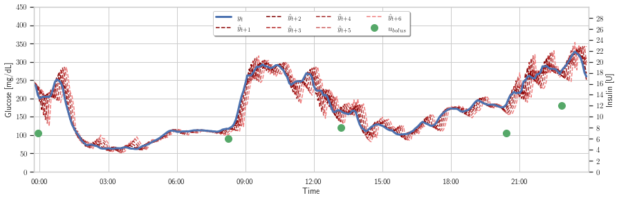

```python
# Parametros
f_ini = pd.Timestamp('2020-01-28 23:45:00')
f_fin = pd.Timestamp('2020-01-29 23:59:59')

# Graficamos
fig, ax = plt.subplots()

ax.plot(Z_test['y+6'][f_ini: f_fin], color='lightcoral',
        linestyle='--', label='$\hat{y}_{t + 6}$')
ax.plot(Z_test['y+5'][f_ini: f_fin], color='indianred',
        linestyle='--', label='$\hat{y}_{t + 5}$')
ax.plot(Z_test['y+4'][f_ini: f_fin], color='brown',
        linestyle='--', label='$\hat{y}_{t + 4}$')
ax.plot(Z_test['y+3'][f_ini: f_fin], color='firebrick',
        linestyle='--', label='$\hat{y}_{t + 3}$')
ax.plot(Z_test['y+2'][f_ini: f_fin], color='maroon',
        linestyle='--', label='$\hat{y}_{t + 2}$')
ax.plot(Z_test['y+1'][f_ini: f_fin], color='darkred',
        linestyle='--', label='$\hat{y}_{t + 1}$')
ax.plot(Z_test['y'][f_ini: f_fin], color='C0', linewidth=3.0
       , label='$y_{t}$')

# Grafico de meal
l1 = ax2 = ax.twinx()
ax2.plot(Z_test['u_bolo'][f_ini: f_fin].replace(0, np.nan).dropna(), marker='o', color='C2',
         label='$u_{bolus}$', linestyle='None', markersize='10')
# parametros del grafico 2
ax2.grid(False)
ax2.tick_params(rotation=0)
ax2.set_ylim([0, 30])
ax2.set_yticks(np.arange(0, 30, 2))
ax2.tick_params(axis='y', pad=5)
ax2.set_ylabel('Insulin [U]')

# Parametros del grafico 1
ax.grid(True)
ax.set_ylim([0, 450])
ax.set_xlim([f_ini, f_fin])
ax.set_ylabel('Glucose [mg/dL]')
ax.set_xlabel('Time')

# leyenda
handles1, labels1 = ax.get_legend_handles_labels()
handles2, labels2 = ax2.get_legend_handles_labels()
handles = handles2 + handles1
labels = labels2 + labels1
handles.reverse()
labels.reverse()
ax.legend(handles, labels, loc= 'upper center', ncol=4, fancybox=True, shadow=True)

# Formato de las fechas
date_form = mdates.DateFormatter('%H:%M')
ax.xaxis.set_major_formatter(date_form)

y_size = 4.2
x_size = 3 * y_size
fig.set_size_inches(x_size, y_size)
plt.tight_layout()

format_name = 'figs/grafico_tiempo_na_48_nb_4_1_bolo'
fig.savefig(format_name + '.svg')
fig.savefig(format_name + '.pdf')
```

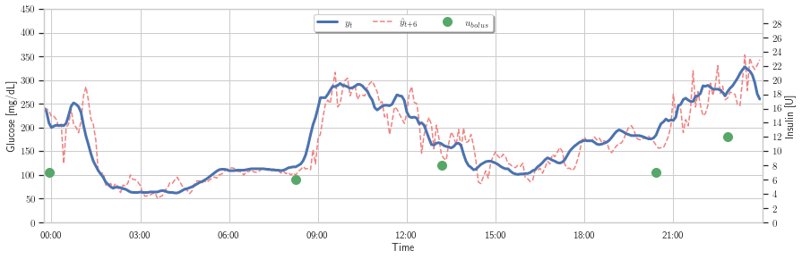

```python
# Parametros
f_ini = pd.Timestamp('2020-01-28 23:45:00')
f_fin = pd.Timestamp('2020-01-29 23:59:59')

# Graficamos
fig, ax = plt.subplots()

ax.plot(Z_test['y+6'][f_ini: f_fin], color='lightcoral',
        linestyle='--', label='$\hat{y}_{t + 6}$')
ax.plot(Z_test['y'][f_ini: f_fin], color='C0', linewidth=3.0
       , label='$y_{t}$')

# Grafico de meal
l1 = ax2 = ax.twinx()
ax2.plot(Z_test['u_bolo'][f_ini: f_fin].replace(0, np.nan).dropna(), marker='o', color='C2',
         label='$u_{bolus}$', linestyle='None', markersize='10')
# parametros del grafico 2
ax2.grid(False)
ax2.tick_params(rotation=0)
ax2.set_ylim([0, 30])
ax2.set_yticks(np.arange(0, 30, 2))
ax2.tick_params(axis='y', pad=5)
ax2.set_ylabel('Insulin [U]')

# Parametros del grafico 1
ax.grid(True)
ax.set_ylim([0, 450])
ax.set_xlim([f_ini, f_fin])
ax.set_ylabel('Glucose [mg/dL]')
ax.set_xlabel('Time')

# leyenda
handles1, labels1 = ax.get_legend_handles_labels()
handles2, labels2 = ax2.get_legend_handles_labels()
handles = handles2 + handles1
labels = labels2 + labels1
handles.reverse()
labels.reverse()
ax.legend(handles, labels, loc= 'upper center', ncol=4, fancybox=True, shadow=True)

# Formato de las fechas
date_form = mdates.DateFormatter('%H:%M')
ax.xaxis.set_major_formatter(date_form)

y_size = 4.2
x_size = 3 * y_size
fig.set_size_inches(x_size, y_size)
plt.tight_layout()

format_name = 'figs/grafico_tiempo_na_48_nb_4_2_bolo'
fig.savefig(format_name + '.svg')
fig.savefig(format_name + '.pdf')
```

### Gráfico del error

- Graficamos el error del training

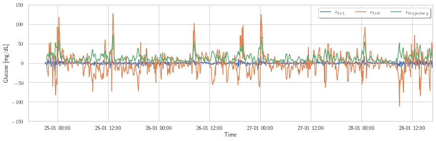

```python
# Parametros
f_ini = Z_train.index[0]
f_fin = Z_train.index[-1]

# Graficamos
fig, ax = plt.subplots()

ax.plot(Z_train['e_1_paso'][f_ini: f_fin], color='C0', linestyle='-', label='$e_{t + 1}$')
ax.plot(Z_train['e_6_paso'][f_ini: f_fin], color='C1', linestyle='-', label='$e_{t + 6}$')
ax.plot(Z_train['e_trajec'][f_ini: f_fin], color='C2', linestyle='-', label='$e_{trajectory}$')

# Parametros
ax.grid(True)
ax.set_ylim([-150, 150])
ax.set_xlim([f_ini, f_fin])
ax.set_ylabel('Glucose [mg/dL]')
ax.set_xlabel('Time')

# leyenda
ax.legend(ncol=4, fancybox=True, shadow=True)

# Formato de las fechas
date_form = mdates.DateFormatter('%d-%m %H:%M')
ax.xaxis.set_major_formatter(date_form)

y_size = 4.2
x_size = 3 * y_size
fig.set_size_inches(x_size, y_size)
plt.tight_layout()

format_name = 'figs/error_grafico_training_na_48_nb_4_bolo'
fig.savefig(format_name + '.svg')
fig.savefig(format_name + '.pdf')
```

- Graficamos el error del testing

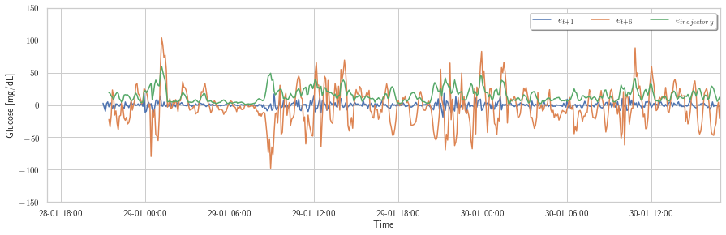

```python
# Parametros
f_ini = Z_test.index[0]
f_fin = Z_test.index[-1]

# Graficamos
fig, ax = plt.subplots()

ax.plot(Z_test['e_1_paso'][f_ini: f_fin], color='C0', linestyle='-', label='$e_{t + 1}$')
ax.plot(Z_test['e_6_paso'][f_ini: f_fin], color='C1', linestyle='-', label='$e_{t + 6}$')
ax.plot(Z_test['e_trajec'][f_ini: f_fin], color='C2', linestyle='-', label='$e_{trajectory}$')

# Parametros
ax.grid(True)
ax.set_ylim([-150, 150])
ax.set_xlim([f_ini, f_fin])
ax.set_ylabel('Glucose [mg/dL]')
ax.set_xlabel('Time')

# leyenda
ax.legend(ncol=4, fancybox=True, shadow=True)

# Formato de las fechas
date_form = mdates.DateFormatter('%d-%m %H:%M')
ax.xaxis.set_major_formatter(date_form)

y_size = 4.2
x_size = 3 * y_size
fig.set_size_inches(x_size, y_size)
plt.tight_layout()

format_name = 'figs/error_grafico_testing_na_48_nb_4_bolo'
fig.savefig(format_name + '.svg')
fig.savefig(format_name + '.pdf')
```

### Análisis en frecuencia del error

- Periodograma para el training

```python
e1 = Z_train['e_1_paso'].dropna()
N = len(e1)
freq = fftfreq(N, 5*60)
E1 = fft(e1, norm='ortho')
E1_N = abs(E1) ** 2
E1_N = pd.Series(E1_N, index=freq)
E1_N = E1_N[freq > 0]

e6 = Z_train['e_6_paso'].dropna()
N = len(e6)
freq = fftfreq(N, 5*60)
E6 = fft(e6, norm='ortho')
E6_N = abs(E6) ** 2
E6_N = pd.Series(E6_N, index=freq)
E6_N = E6_N[freq > 0]

ee = Z_train['e_trajec'].dropna()
N = len(ee)
freq = fftfreq(N, 5*60)
EE = fft(ee, norm='ortho')
EE_N = abs(EE) ** 2
EE_N = pd.Series(EE_N, index=freq)
EE_N = EE_N[freq > 0]
```

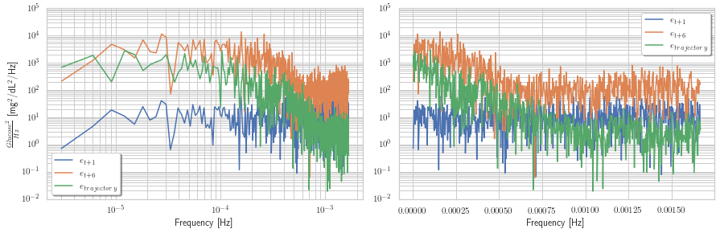

```python
# Creamos la figura y el axis
fig, (ax1, ax2) = plt.subplots(1, 2)

# Realizamos el grafico
ax1.loglog(E1_N, color='C0', label=r'$e_{t+1}$')
ax1.loglog(E6_N, color='C1', label=r'$e_{t+6}$')
ax1.loglog(EE_N, color='C2', label=r'$e_{trajectory}$')

ax2.semilogy(E1_N, color='C0', label=r'$e_{t+1}$')
ax2.semilogy(E6_N, color='C1', label=r'$e_{t+6}$')
ax2.semilogy(EE_N, color='C2', label=r'$e_{trajectory}$')

# Configuramos los parametros
ax1.grid(True, which='both')
ax1.set_ylim([10 ** (-2), 10 ** 5])
ax1.legend(fancybox=True, shadow=True)

ax2.grid(True, which='both')
ax2.set_ylim([10 ** (-2), 10 ** 5])
ax2.legend(fancybox=True, shadow=True)

ax1.set_ylabel(r'$\frac{Glucose^2}{Hz}$ [mg$^2$/dL$^2$/Hz]')
ax1.set_xlabel(r'Frequency [Hz]')
ax2.set_xlabel(r'Frequency [Hz]')

x_size = 3 * 4.2
y_size = 1 * x_size / 3
fig.set_size_inches(x_size, y_size)
plt.tight_layout()

format_name = 'figs/error_periodograma_training_na_48_nb_4_bolo'
fig.savefig(format_name + '.svg')
fig.savefig(format_name + '.pdf')
```

- Periodograma para el testing

```python
e1 = Z_test['e_1_paso'].dropna()
N = len(e1)
freq = fftfreq(N, 5*60)
E1 = fft(e1, norm='ortho')
E1_N = abs(E1) ** 2
E1_N = pd.Series(E1_N, index=freq)
E1_N = E1_N[freq > 0]

e6 = Z_test['e_6_paso'].dropna()
N = len(e6)
freq = fftfreq(N, 5*60)
E6 = fft(e6, norm='ortho')
E6_N = abs(E6) ** 2
E6_N = pd.Series(E6_N, index=freq)
E6_N = E6_N[freq > 0]

ee = Z_test['e_trajec'].dropna()
N = len(ee)
freq = fftfreq(N, 5*60)
EE = fft(ee, norm='ortho')
EE_N = abs(EE) ** 2
EE_N = pd.Series(EE_N, index=freq)
EE_N = EE_N[freq > 0]
```

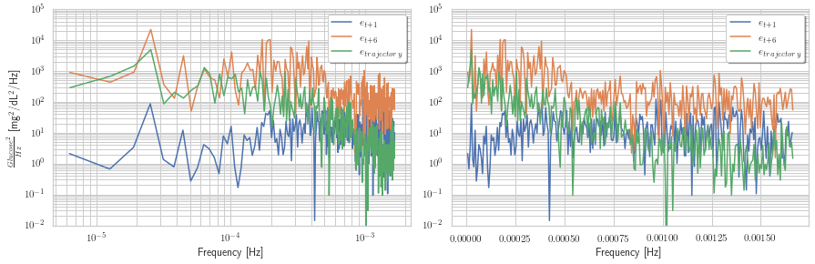

```python
# Creamos la figura y el axis
fig, (ax1, ax2) = plt.subplots(1, 2)

# Realizamos el grafico
ax1.loglog(E1_N, color='C0', label=r'$e_{t+1}$')
ax1.loglog(E6_N, color='C1', label=r'$e_{t+6}$')
ax1.loglog(EE_N, color='C2', label=r'$e_{trajectory}$')

ax2.semilogy(E1_N, color='C0', label=r'$e_{t+1}$')
ax2.semilogy(E6_N, color='C1', label=r'$e_{t+6}$')
ax2.semilogy(EE_N, color='C2', label=r'$e_{trajectory}$')

# Configuramos los parametros
ax1.grid(True, which='both')
ax1.set_ylim([10 ** (-2), 10 ** 5])
ax1.legend(fancybox=True, shadow=True)

ax2.grid(True, which='both')
ax2.set_ylim([10 ** (-2), 10 ** 5])
ax2.legend(fancybox=True, shadow=True)

ax1.set_ylabel(r'$\frac{Glucose^2}{Hz}$ [mg$^2$/dL$^2$/Hz]')
ax1.set_xlabel(r'Frequency [Hz]')
ax2.set_xlabel(r'Frequency [Hz]')

x_size = 3 * 4.2
y_size = 1 * x_size / 3
fig.set_size_inches(x_size, y_size)
plt.tight_layout()

format_name = 'figs/error_periodograma_testing_na_48_nb_4_bolo'
fig.savefig(format_name + '.svg')
fig.savefig(format_name + '.pdf')
```

- Espectro para el training

```python
e1 = Z_train['e_1_paso'].dropna()
e6 = Z_train['e_6_paso'].dropna()
ee = Z_train['e_trajec'].dropna()

R_e1 = np.correlate(e1, e1, mode='full') / N
R_e6 = np.correlate(e6, e6, mode='full') / N
R_ee = np.correlate(ee, ee, mode='full') / N

N1 = len(R_e1)
N6 = len(R_e6)
Ne = len(R_ee)

# Gamma = N/2
gamma = round(N1 / 2) - 1
phi_E1 = phi_X(R_e1, gamma)

gamma = round(N6 / 2) - 1
phi_E6 = phi_X(R_e6, gamma)

gamma = round(Ne / 2) - 1
phi_EE = phi_X(R_ee, gamma)
```

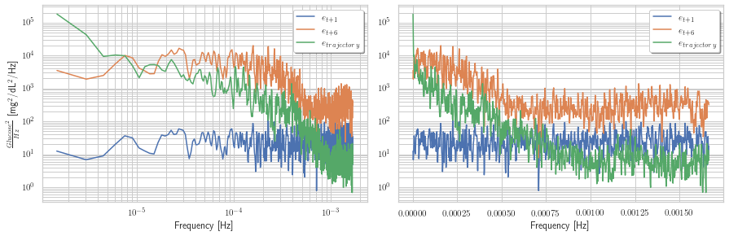

```python
# Creamos la figura y el axis
fig, (ax1, ax2) = plt.subplots(1, 2)

# Realizamos el grafico
ax1.loglog(abs(phi_E1), color='C0', label=r'$e_{t+1}$')
ax1.loglog(abs(phi_E6), color='C1', label=r'$e_{t+6}$')
ax1.loglog(abs(phi_EE), color='C2', label=r'$e_{trajectory}$')

ax2.semilogy(abs(phi_E1), color='C0', label=r'$e_{t+1}$')
ax2.semilogy(abs(phi_E6), color='C1', label=r'$e_{t+6}$')
ax2.semilogy(abs(phi_EE), color='C2', label=r'$e_{trajectory}$')

# Configuramos los parametros
ax1.grid(True, which='both')
#ax1.set_ylim([10 ** (-2), 10 ** 6])
#ax1.set_xlim([10 ** (-6), max(Y_N.index)])
ax1.legend(fancybox=True, shadow=True)

ax2.grid(True, which='both')
#ax2.set_ylim([10 ** (-2), 10 ** 6])
#ax2.set_xlim([10 ** (-6), max(Y_N.index)])
ax2.legend(fancybox=True, shadow=True)

ax1.set_ylabel(r'$\frac{Glucose^2}{Hz}$ [mg$^2$/dL$^2$/Hz]')
ax1.set_xlabel(r'Frequency [Hz]')
ax2.set_xlabel(r'Frequency [Hz]')

x_size = 3 * 4.2
y_size = 1 * x_size / 3
fig.set_size_inches(x_size, y_size)
plt.tight_layout()

format_name = 'figs/error_espectro_training_na_48_nb_4_bolo'
fig.savefig(format_name + '.svg')
fig.savefig(format_name + '.pdf')
```

- Espectro para el testing

```python
e1 = Z_test['e_1_paso'].dropna()
e6 = Z_test['e_6_paso'].dropna()
ee = Z_test['e_trajec'].dropna()

R_e1 = np.correlate(e1, e1, mode='full') / N
R_e6 = np.correlate(e6, e6, mode='full') / N
R_ee = np.correlate(ee, ee, mode='full') / N

N1 = len(R_e1)
N6 = len(R_e6)
Ne = len(R_ee)

# Gamma = N/2
gamma = round(N1 / 2) - 1
phi_E1 = phi_X(R_e1, gamma)

gamma = round(N6 / 2) - 1
phi_E6 = phi_X(R_e6, gamma)

gamma = round(Ne / 2) - 1
phi_EE = phi_X(R_ee, gamma)
```

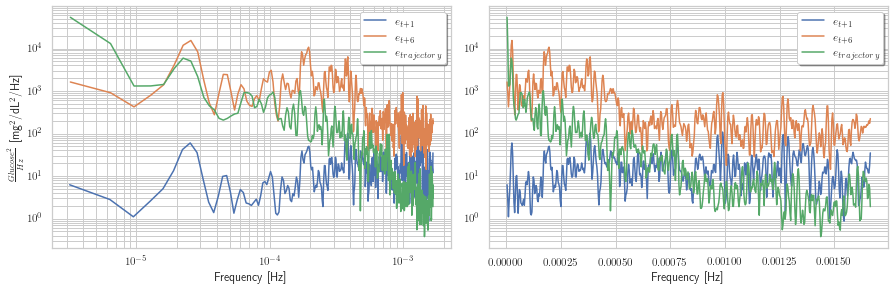

```python
# Creamos la figura y el axis
fig, (ax1, ax2) = plt.subplots(1, 2)

# Realizamos el grafico
ax1.loglog(abs(phi_E1), color='C0', label=r'$e_{t+1}$')
ax1.loglog(abs(phi_E6), color='C1', label=r'$e_{t+6}$')
ax1.loglog(abs(phi_EE), color='C2', label=r'$e_{trajectory}$')

ax2.semilogy(abs(phi_E1), color='C0', label=r'$e_{t+1}$')
ax2.semilogy(abs(phi_E6), color='C1', label=r'$e_{t+6}$')
ax2.semilogy(abs(phi_EE), color='C2', label=r'$e_{trajectory}$')

# Configuramos los parametros
ax1.grid(True, which='both')
#ax1.set_ylim([10 ** (-2), 10 ** 6])
#ax1.set_xlim([10 ** (-6), max(Y_N.index)])
ax1.legend(fancybox=True, shadow=True)

ax2.grid(True, which='both')
#ax2.set_ylim([10 ** (-2), 10 ** 6])
#ax2.set_xlim([10 ** (-6), max(Y_N.index)])
ax2.legend(fancybox=True, shadow=True)

ax1.set_ylabel(r'$\frac{Glucose^2}{Hz}$ [mg$^2$/dL$^2$/Hz]')
ax1.set_xlabel(r'Frequency [Hz]')
ax2.set_xlabel(r'Frequency [Hz]')

x_size = 3 * 4.2
y_size = 1 * x_size / 3
fig.set_size_inches(x_size, y_size)
plt.tight_layout()

format_name = 'figs/error_espectro_testing_na_48_nb_4_bolo'
fig.savefig(format_name + '.svg')
fig.savefig(format_name + '.pdf')
```